# Vehicle Detection Project

The goals / steps of this project are the following:

- Perform a Histogram of Oriented Gradients (HOG) feature extraction on a labeled training set of images and train a classifier Linear SVM classifier
- Optionally, you can also apply a color transform and append binned color features, as well as histograms of color, to your HOG feature vector.
- Note: for those first two steps don't forget to normalize your features and randomize a selection for training and testing.
- Implement a sliding-window technique and use your trained classifier to search for vehicles in images.
- Run your pipeline on a video stream (start with the test_video.mp4 and later implement on full project_video.mp4) and create a heat map of recurring detections frame by frame to reject outliers and follow detected vehicles.
- Estimate a bounding box for vehicles detected.

```python
import cv2
import glob
import pickle
import numpy as np
import tools as t

from scipy.ndimage.measurements import label
from IPython.display import HTML
```

# Histogram of Oriented Gradients (HOG)

### *Explain how (and identify where in your code) you extracted HOG features from the training images. Explain how you settled on your final choice of HOG parameters.*

I used extracted HOG features in two places. First, I extracted HOG features from the training datasets upon loading them, for use in the training of vehicle classifier. For this I used the function in `tools.py` called `tools.get_hog_features`, which is a minor modification of the starter code provided by Udacity.

Second I extracted HOG features over the region of interest when window searching frames for vehicle signatures. For this I used the starter code provided by Udacity, which you can see in `tools.find_cars`. I had a rough time with this code, including 4 long hours between 12 am and 4 am, due to various array sizing, scaling, and color conversion issues. Of course, it is a complex task, so it was going to be hard.

I stuck, by in large, to the baseline parameters that were included with the starter code. However, I did switch to the colorspace `YCrCb`, based on getting better results and fiddling with a few other spaces. If time allows, I may try out `YUV`. I found my results improved if I employed all channels, so I did.

### *Describe how (and identify where in your code) you trained a classifier using your selected HOG features (and color features if you used them).*

I also used spatial binning of color and color histograms in my classifier, again making use of the starter code, and sticking to the initial parameters.

I trained a number of different linear SVM classifiers. Initially, I was very happy to see that the classifiers performed nearly perfectly on the KITTI and GTI datasets, train and test. **I should have been suspicious.** What I found through confused and painful experimentation is that I had a highly overfit classifier. Not overfit in the sense of overfitting the training set and underperforming on the test data, but overfit in terms of being very very well suited to the particular bias of the KITTI and GTI datasets, but performing poorly on the actual video. With these overfit classifier, when I would run `find cars` on the image, I would get huge numbers of false positives, like so:

[figure not shown]

This example is from another student, who posted it in [this thread](https://discussions.udacity.com/t/false-positives-on-detection/245593/13) on the forum. It's a layered error that can be from errors in color conversion, scaling, inconsistent scaling and transformation pipeline. I found that even after correcting those, I still had the error.

I settled on regularizing with PCA. I ran `PCA` then `LinearSVC`, steadily increasing the number of PCA components:

```
========
Dims = 10
% Variation Explained: 0.464669522615
Test data accuracy:    0.513795045045
========
Dims = 20
% Variation Explained: 0.61185151492
Test data accuracy:    0.758727477477
========
Dims = 30
% Variation Explained: 0.704896507947
Test data accuracy:    0.879786036036
========
Dims = 40
% Variation Explained: 0.765749007704
Test data accuracy:    0.869087837838
========
Dims = 50
% Variation Explained: 0.812780031474
Test data accuracy:    0.927927927928
========
Dims = 60
% Variation Explained: 0.848039486267
Test data accuracy:    0.874436936937
========
Dims = 70
% Variation Explained: 0.87557836731
Test data accuracy:    0.892173423423
========
Dims = 80
% Variation Explained: 0.895200547322
Test data accuracy:    0.931024774775
```

I stopped at 80 PCA components. Since these 80 components did not capture 11% of variation, I knew I was leaving in a good bit of noise that SVM would have trouble fitting. And I figured with 93% accuracy on this dataset, my classifier might not be so tightly tailored to KITTI and GTI, and it might generalize better. I found this to be the case when my false positive rate went down a factor of 10.

I scaled features before PCA with `sklearn.preprocessing.StandardScaler` so that my final data processing pipeline looked like:

1. Convert to colorspace `YCrCb`
2. Extract spatial binning, color histogram, and 3-channel HOG features
3. Standard scaling
4. Reduce to 80 PCA factors
5. Run SVM prediction

### Improvements

# Sliding Window Search

### *Describe how (and identify where in your code) you implemented a sliding window search. How did you decide what scales to search and how much to overlap windows?*

I mostly leaned on the starter code provided by Udacity and the basic parameters provided by Udacity. I did take care to maintain the ability to pass changes to these parameters through my pipeline, to allow for experimentation when I have more opportunity. However, debugging was very intense.

For scales, I eyeballed the images and then plotted some squares on them to get a sense for what scales might make sense.

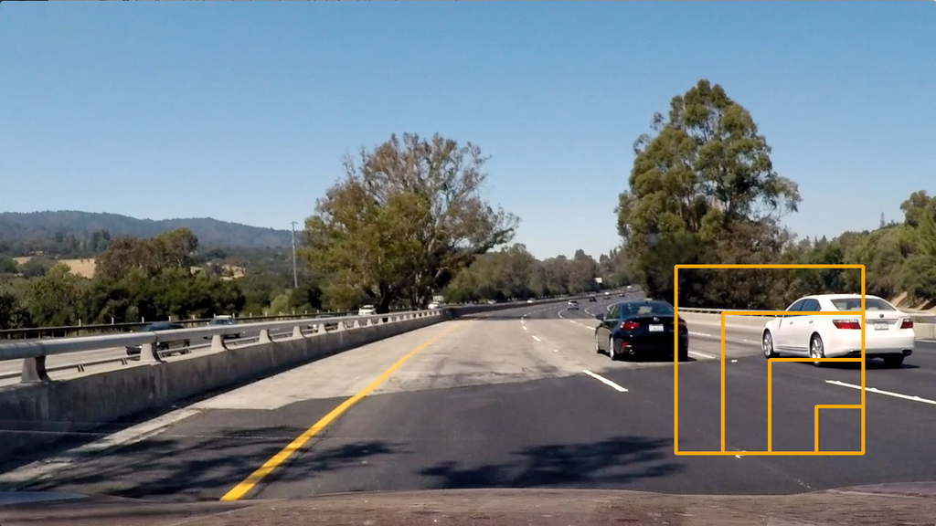

```python
image = t.load_image('test_images/test4.jpg')
p0, p1, p2, p3, p4 = [(1180 - n * 64, 620 - n * 64) for n in range(5)]
cv2.rectangle(image, p0, p1, (255, 168, 7), thickness = 3)
cv2.rectangle(image, p0, p2, (255, 168, 7), thickness = 3)
cv2.rectangle(image, p0, p3, (255, 168, 7), thickness = 3)
cv2.rectangle(image, p0, p4, (255, 168, 7), thickness = 3)
t.showarray(image)
```

Based on the above I chose to scan a region of interest using Scale 1 and Scale 2 only. Scale 3 was far larger than any vehicle in the sample video, and Scale 4 moreso. Going below Scale 1 would imply downsampling at current settings, so I didn't experiment with that. After tinkering with these two scales, I decided they were adequate. I do think one might be able to suffice with Scale 2 alone.

### *Show some examples of test images to demonstrate how your pipeline is working. How did you optimize the performance of your classifier?*

Optimize? Just getting it to work was hard enough. Just kidding. I did a lot to optimize it, but there's still some ways to go. Here's a few of the things I tried:

`heatmap = alpha * new_heatmap + (1 - alpha) * old_heatmap`

- Tuning thresholds for binarizing the heatmap and tuning the number of frames averaged. For tuning the threshold and the # of frames I tinkered a lot with generating clips. I found that you can average many more frames than you think and not get too much lag. 20 frames is not that long a time in highway conditions, so you don't get too much lag.
- using a double looped heatmap update where any box overlapping another box doubled it's vote (see `tools.add_heat`). This was suggested on the forum as a way to deal with vehicle bounding boxes that did not fully contain the vehicle. Clever solution.

I found that tinkering too much with the frame level extraction of heatmaps did not pay off nearly as much as tinkering with frame by frame methods. The movement of the vehicle provides a kind of moving filter where, if a region of the image is throwing false positives, the objects in that region will soon move on. Whereas, the vehicles' relative positions' are much more stable, so they pass this moving filter.

Below you can see some images showing how sensitive the frame by frame heatmaps are to the threshold settings. Many frames with railing and shadows are far worse.

```python
import warnings
warnings.filterwarnings("ignore", category=DeprecationWarning)

scaler = pickle.load(open('vars/scaler.p', 'rb'))
pca3 = pickle.load(open('vars/pca3.p', 'rb'))
svc3 = pickle.load(open('vars/svc3.p', 'rb'))

heatmap = np.zeros((720, 1280))
images = [t.load_image(filename) for filename in glob.glob('frames/frame096*.jpg')[:6]]

for image in images:
    for scale in [1, 2]:
        boxes = t.find_cars(img=image,
                             ystart=400,
                             ystop=656,
                             scale=scale,
                             svc=svc3,
                             transformer= lambda f: pca3.transform(scaler.transform(f)),
                             orient=9,
                             pix_per_cell=8,
                             cell_per_block=2,
                             spatial_size=(32,32),
                             hist_bins=32,
                             visualize=False
                            )

        t.add_heat(heatmap, boxes, amount=1)
```

```
/Users/alexcthompson/anaconda3/envs/keras12/lib/python3.5/site-packages/skimage/feature/_hog.py:119: skimage_deprecation: Default value of `block_norm`==`L1` is deprecated and will be changed to `L2-Hys` in v0.15
  'be changed to `L2-Hys` in v0.15', skimage_deprecation)
```

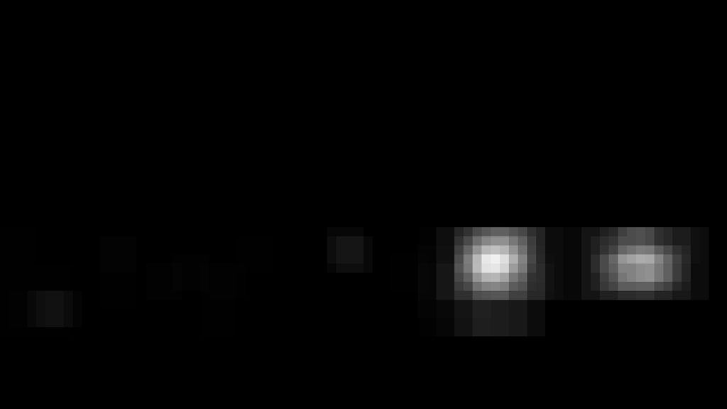

```
4 cars found
```

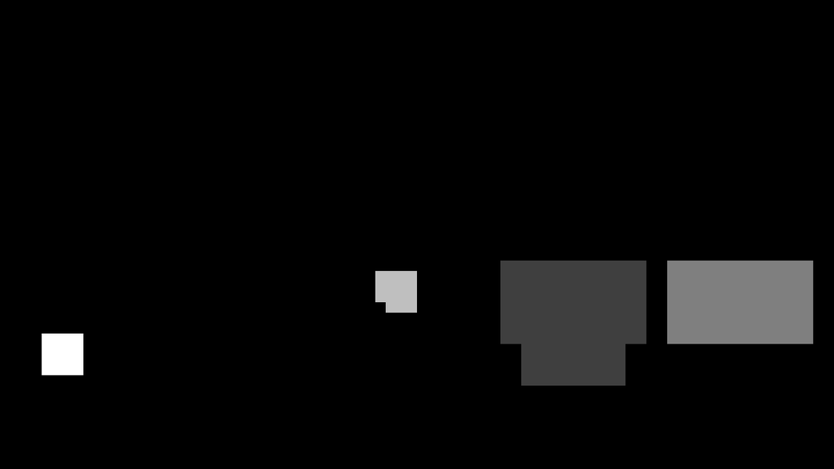

```
3 cars found
```

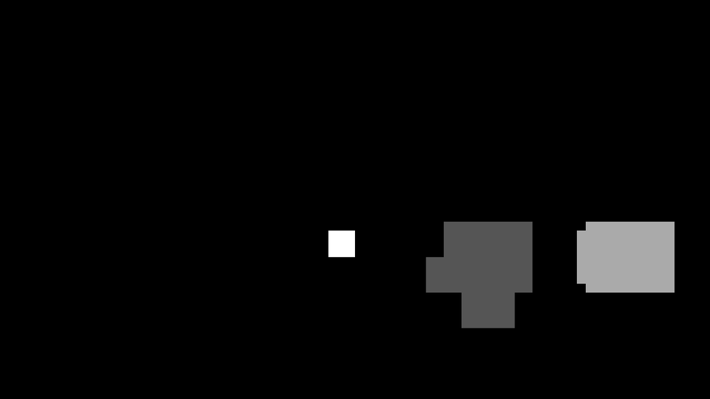

```
2 cars found
```

[figure not shown]

```
2 cars found
```

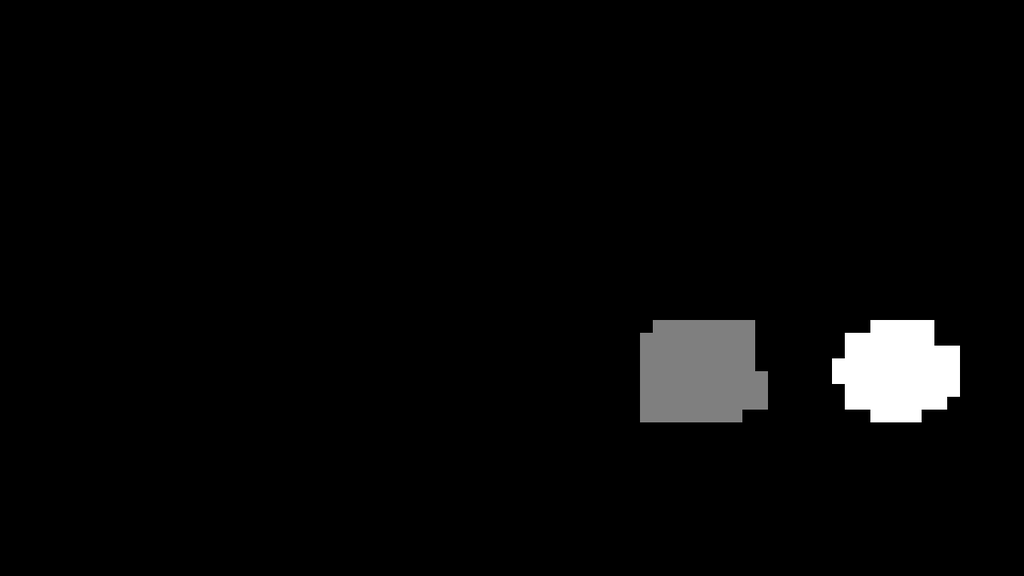

```python
t.showarray(heatmap)

for threshold in [10, 20, 30, 40]:
    heatmap_t = t.apply_threshold(heatmap, threshold)
    labels = label(heatmap_t)

    print(labels[1], 'cars found')

    t.showarray(labels[0] * 255 / labels[1])
```

# Video Implementation

### *Provide a link to your final video output. Your pipeline should perform reasonably well on the entire project video (somewhat wobbly or unstable bounding boxes are ok as long as you are identifying the vehicles most of the time with minimal false positives.)*

## Here's my final video:

```python
HTML("""
<video width="640" height="360" controls>
  <source src="{0}">
</video>
""".format('project_output.mp4'))
```

[video not shown]

### *Describe how (and identify where in your code) you implemented some kind of filter for false positives and some method for combining overlapping bounding boxes.*

I already described quite a bit of this above, but let's see how summing heatmaps across frames, tuning the voting threshold, and using the overlapping vote trick (double voting loop) can improve our results.

Let's compare three videos. Here's a video with no double voting loop, looking back over 10 frames, with a 25 vote threshold for vehicle identification:

```python
HTML("""
<video width="640" height="360" controls>
  <source src="{0}">
</video>
""".format('examples/project_output_10f_25t.mp4'))
```

[video not shown]

You can see that there are quite a few false positives, especially along the railing, and the bounding boxes are often too small.

```python
HTML("""
<video width="640" height="360" controls>
  <source src="{0}">
</video>
""".format('examples/project_output_20f_40t_nodouble.mp4'))
```

[video not shown]

This seems to have cured our false positive problem, but our bounding boxes are a bit cramped. If bounding boxes inform distance estimates, I would rather have our algorithm believe the car is visually bigger (and therefore closer) than smaller, so let's add the double voting loop trick, where boxes with overlap add twice the heatmap:

```python
HTML("""
<video width="640" height="360" controls>
  <source src="{0}">
</video>
""".format('examples/project_output_20f_80t.mp4'))
```

[video not shown]

The white car is still tricky but this is much improved.

# Discussion

This algorithm is very vulnerable, in particular I think the following could trip it up:

- Traffic conditions where other traffic is not some what stationary relatively speaking.
- Different lighting conditions.
- It performs less well on white cars, apparently a problem many are having.
- It frequenty is confused by things that look sort of like cars - like metal railings or odd shadow patterns. I have seen this in DNNs trained for vehicle recognition, where it will mistake an air conditioning unit on top of a building for a vehicle.

I think a fast DNN would be a good supplement or replacement for part of this pipeline. I also think there is lots of room for optimization. The other problem here is compute. This thing computes 1 frame per 2 seconds, so it's not real time. I'm sure a C++ implementation optimized on a GPU would perform better, but this needs work.

Here are some improvements that I think can be made:

- Work off sensor level higher dynamic range data
- Down sample by 1/2 or 1/3 by subsampling pixels (not interpolating).
- Skip frames.
- Tune all parameters.
- It seems like some people get slightly better results with YUV than YCrCb.
- Reduce to 1 or 2 HOG channels and reduce sampling.
- Train against Udacity dataset.
- Enhance lane line algorithm to identify driveable space, then only look there for vehicles.
- Fuse Lidar data, drop compute intensive methods above and look for reflective surfaces instead.